# FitBit Analysis

2022-11-22

# Überblick Datenerhebung

[figure not shown]

# Überblick Daten

| time | heart_rate | ID | time_span | gender | age | teaching_experience | disruption_factor | confident_factor | event |
| --- | --- | --- | --- | --- | --- | --- | --- | --- | --- |
| 0 | 70 | 101 | overall | male | 22 | 0 | 7 | 4 | heckling |
| 0 | 70 | 101 | overall | male | 22 | 0 | 2 | 5 | head on table |
| 0 | 70 | 101 | overall | male | 22 | 0 | 3 | 9 | drawing |
| 0 | 70 | 101 | overall | male | 22 | 0 | 7 | 6 | snipping |
| 0 | 70 | 101 | overall | male | 22 | 0 | 2 | 8 | whispering |
| 0 | 70 | 101 | overall | male | 22 | 0 | 10 | 3 | chatting |
| 0 | 70 | 101 | overall | male | 22 | 0 | 9 | 3 | clicking pen |
| 0 | 70 | 101 | overall | male | 22 | 0 | 4 | 7 | looking at phone |
| 0 | 70 | 101 | overall | male | 22 | 0 | 0 | 10 | drumming |
| 15 | 70 | 101 | overall | male | 22 | 0 | 7 | 4 | heckling |

# Plot für einzelne Phasen

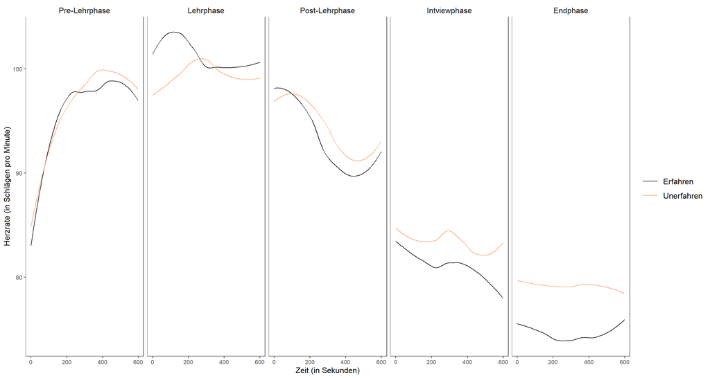

# Geschlecht

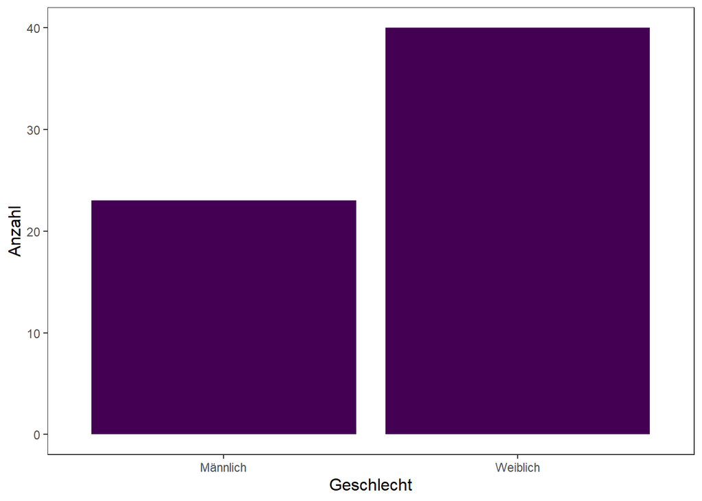

# Alter

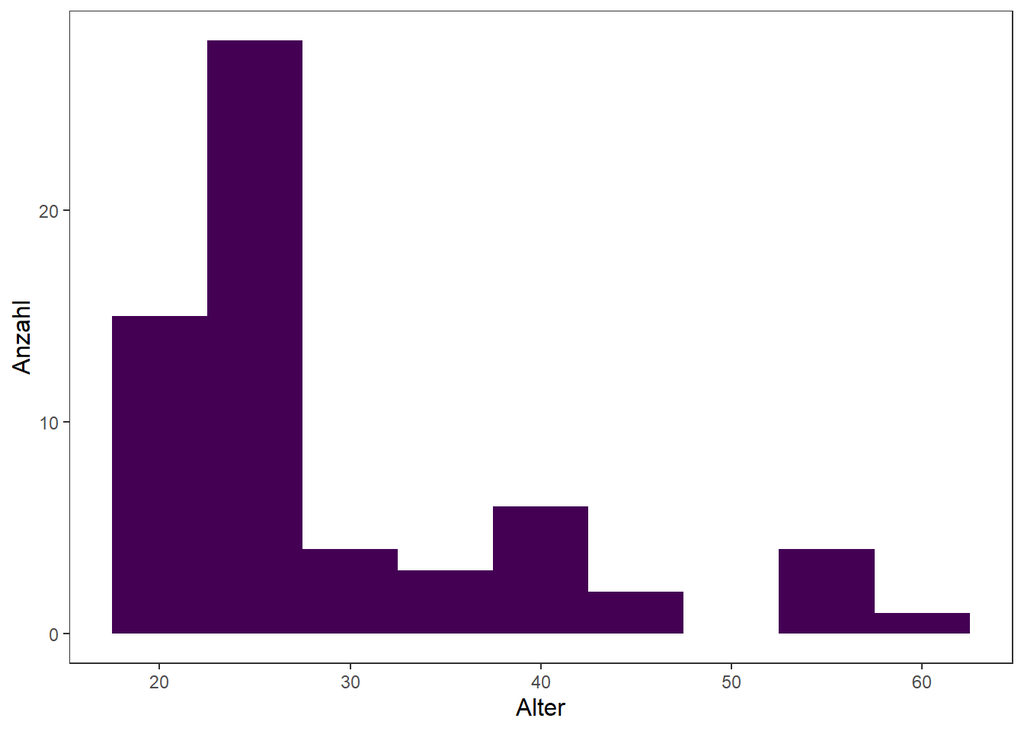

- Linkssteile Verteilung
- Möglicher Umgang: Logarithmieren

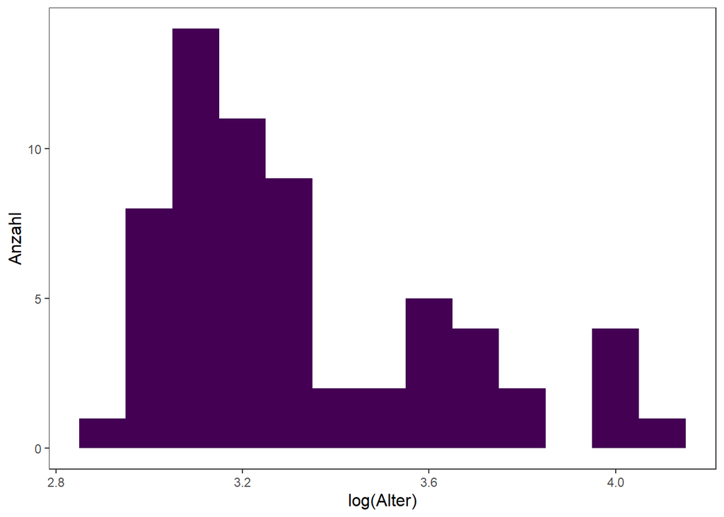

# Alter x Geschlecht

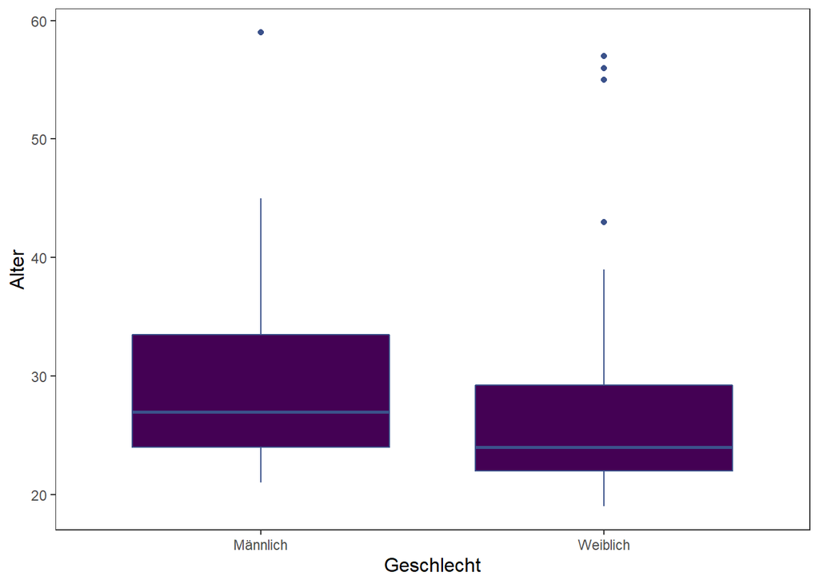

- Alter und Geschlecht unkorreliert
- $\chi^2=$ 32.15

# Lehrerfahrung

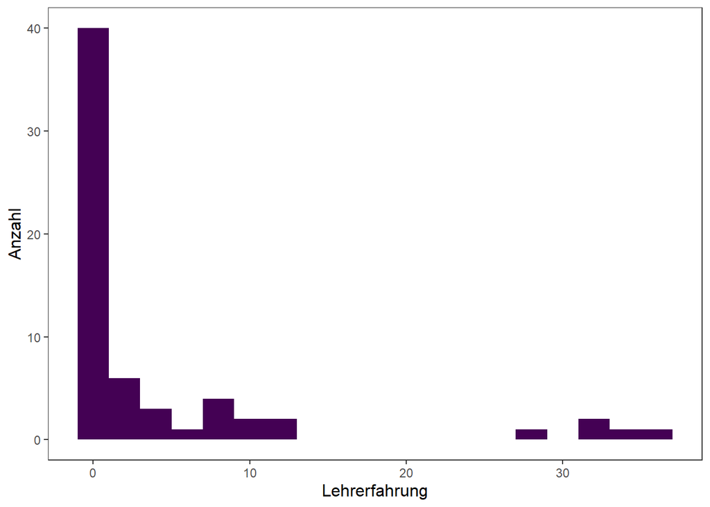

- Starke links-verzerrte Verteilung (zero inflation)
- 0 rausfiltern (keine Option)
- log(x + 1)

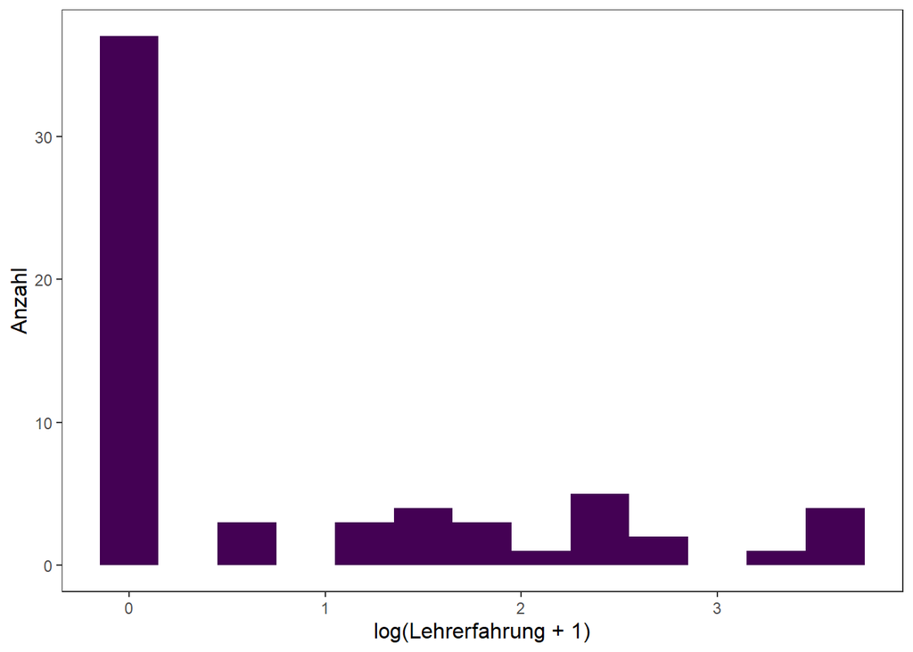

- In jedem Fall stark korreliert mit Alter $\rightarrow$ Gefahr der Multikollinearität
- r = 0.94
- Vorschlag: Lehrerfahrung weglassen und Alter aufnehmen
- Konsistent mit Idee, Expert*innen und Noviz*innen nicht zu trennen

## Confident Factor

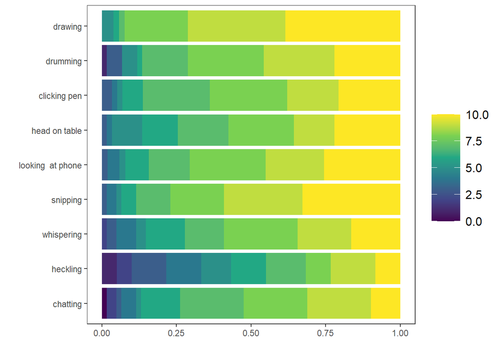

## Disruption Factor

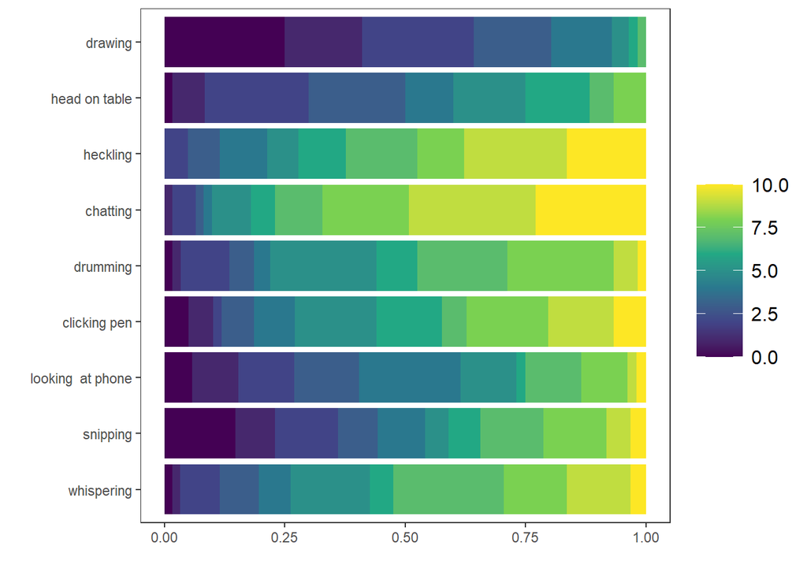

- Mittelwerte bilden? (potentielle Aussagekraft: Im Schnitt fühlten sich manche Lehrpersonen sicherer mit der Situation/fühlten sich eher gestört von der Situation)

# Erste Zusammenhänge

## Confidence x Disruption (out of curiosity)

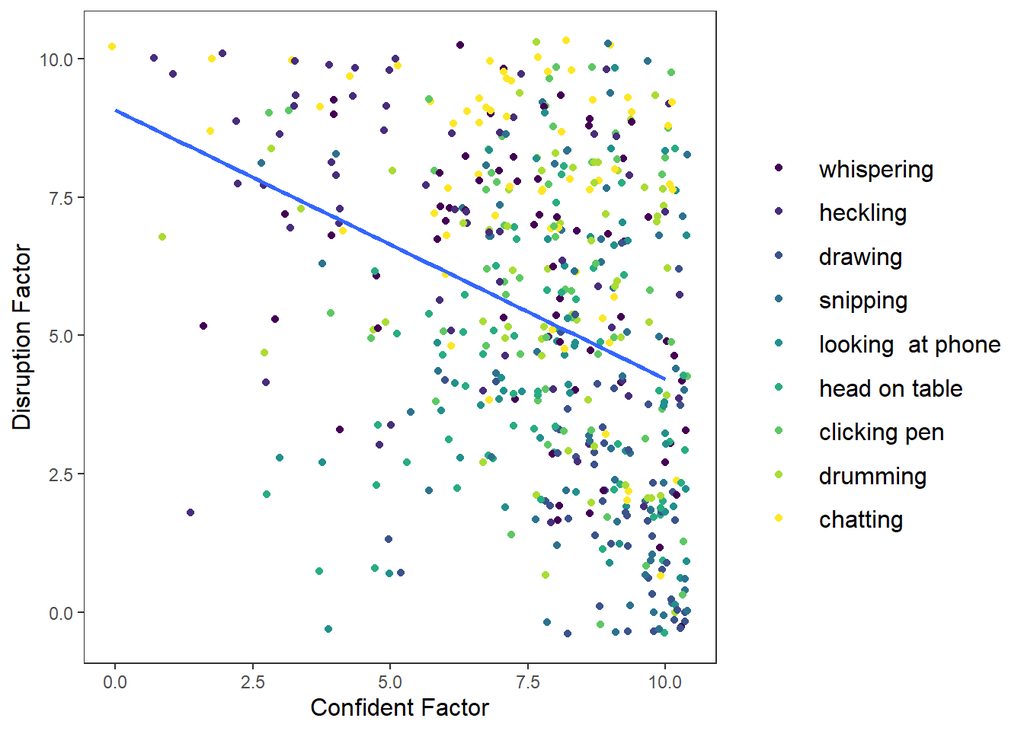

## Alter x Confidence

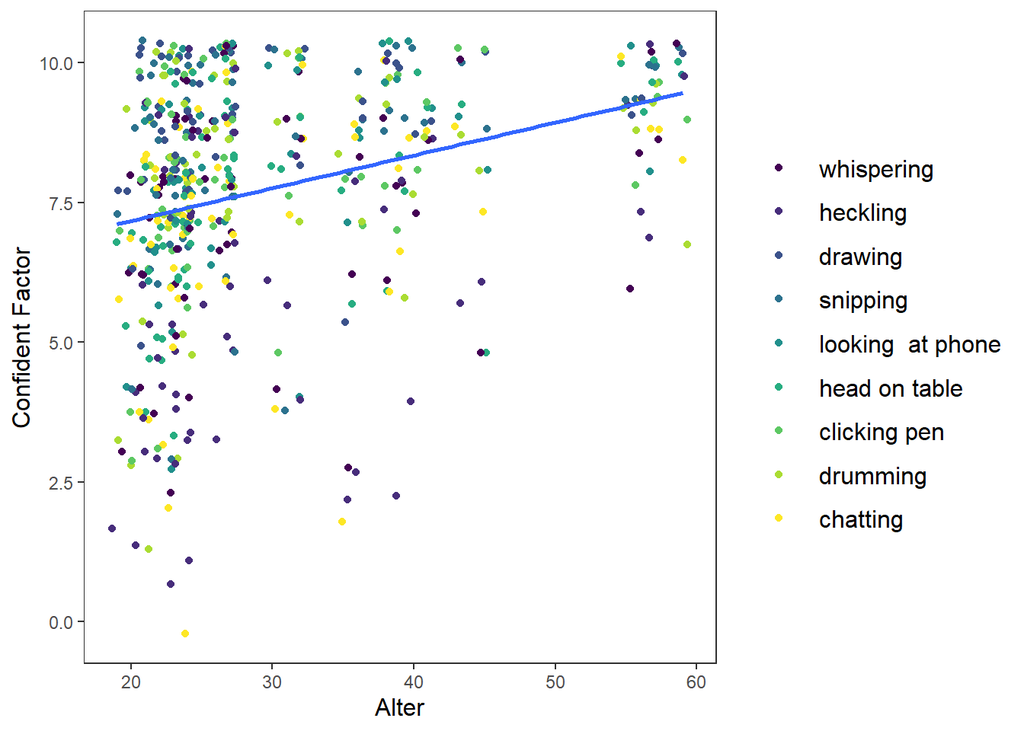

- Mittelwerte:

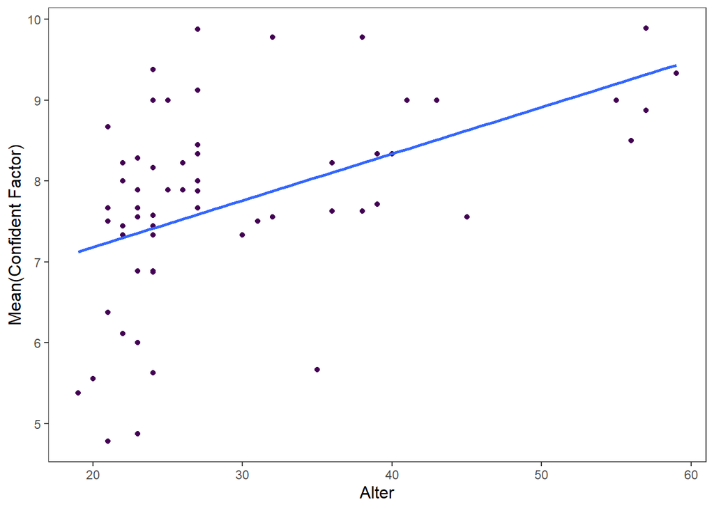

## Alter x Disruption

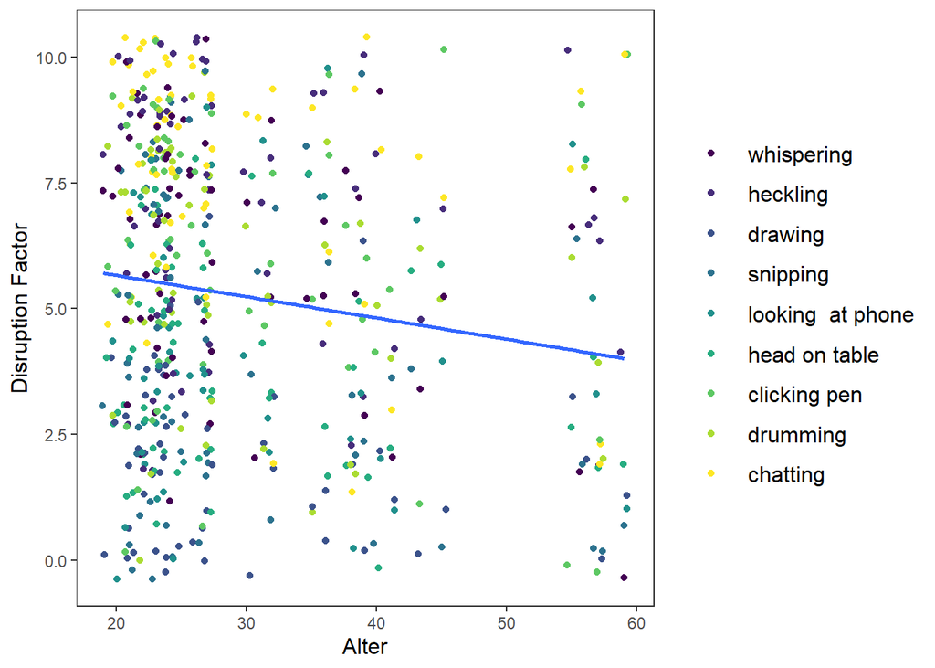

- Mittelwerte:

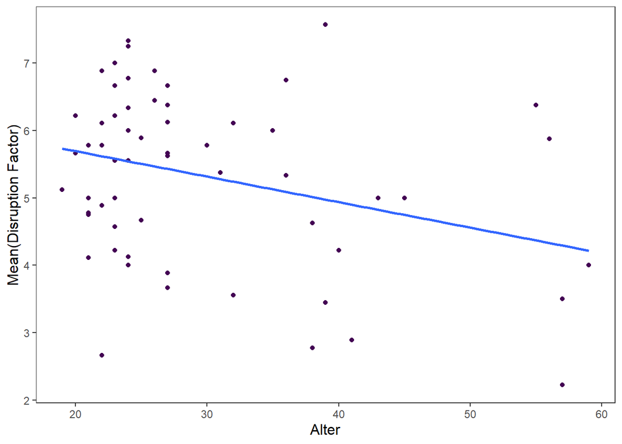

# Heart Rate

Vorüberlegungen

## Beispiel (Pre-Phase)

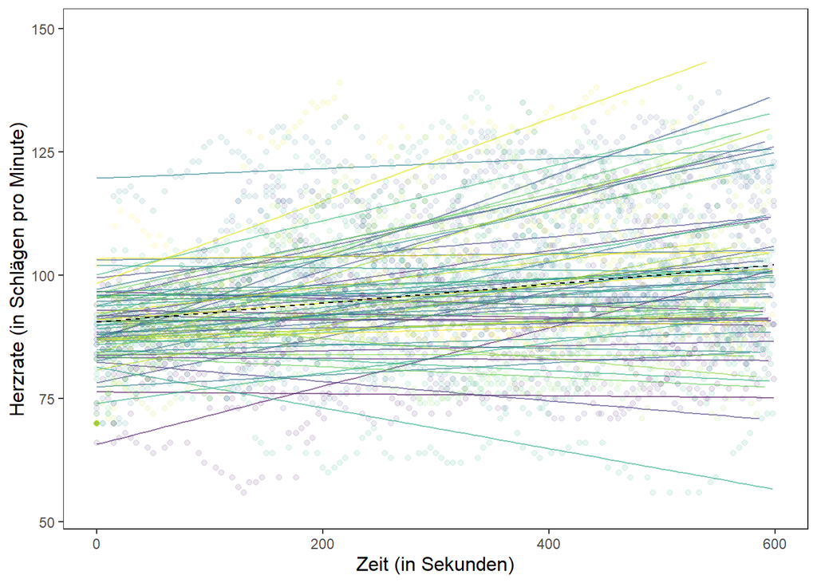

| ID | Estimate |
| --- | --- |
| 101 | -0.0019679 |
| 102 | 0.0030396 |
| 103 | 0.0610070 |
| 104 | -0.0016105 |
| 105 | -0.0048183 |
| 106 | 0.0009613 |
| 107 | 0.0068153 |
| 108 | 0.0354795 |
| 109 | -0.0014359 |

Plan für Pre- und Subsequent Phase:

- Partielle Korrelationen
- Multiple Lineare Regression
  - AV: Estimate
  - UV: Gender, Alter, Disruption Factor (mean), Confident Factor (mean)
  - Alle metrischen Variablen sind standardisiert

## Pre Phase

- 10 Minuten nach Anlegen der FitBit

### Korrelationen

|  | Estimate | confident_factor_m | disruption_factor_m | gender | age |
| --- | --- | --- | --- | --- | --- |
| Estimate | 1.00 | -0.17 | 0.15 | 0.14 | 0.17 |
| confident_factor_m | -0.17 | 1.00 | -0.13 | 0.20 | 0.58 |
| disruption_factor_m | 0.15 | -0.13 | 1.00 | 0.02 | -0.10 |
| gender | 0.14 | 0.20 | 0.02 | 1.00 | -0.30 |
| age | 0.17 | 0.58 | -0.10 | -0.30 | 1.00 |

|  | Estimate | confident_factor_m | disruption_factor_m | gender | age |
| --- | --- | --- | --- | --- | --- |
| Estimate | 0.000 | 0.422 | 0.544 | 0.769 | 0.834 |
| confident_factor_m | 0.422 | 0.000 | 0.370 | 0.982 | 0.001 |
| disruption_factor_m | 0.544 | 0.370 | 0.000 | 0.815 | 0.072 |
| gender | 0.769 | 0.982 | 0.815 | 0.000 | 0.661 |
| age | 0.834 | 0.001 | 0.072 | 0.661 | 0.000 |

### Regression

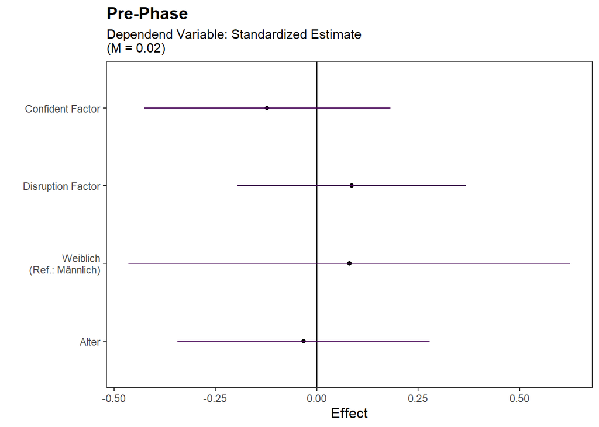

- Keine sign. Ergebnisse
- Selbstbewusste Personen haben einen *niedrigeren* Anstieg der HR vor der Erhebung
- Personen, die sich stärker gestört gefühlt haben, haben einen *stärkeren* Anstieg der HR
- Die HR von Frauen steigt *stärker* als die der Männer
- Je älter die Personen sind, desto *niedriger* ist der Anstieg der HR

## Subsequent Phase

- 10 Minuten nach der Unterrichtseinheit

### Korrelation

|  | Estimate | confident_factor_m | disruption_factor_m | gender | age |
| --- | --- | --- | --- | --- | --- |
| Estimate | 1.00 | 0.15 | -0.28 | -0.27 | -0.28 |
| confident_factor_m | 0.15 | 1.00 | -0.11 | 0.21 | 0.58 |
| disruption_factor_m | -0.28 | -0.11 | 1.00 | -0.03 | -0.15 |
| gender | -0.27 | 0.21 | -0.03 | 1.00 | -0.34 |
| age | -0.28 | 0.58 | -0.15 | -0.34 | 1.00 |

|  | Estimate | confident_factor_m | disruption_factor_m | gender | age |
| --- | --- | --- | --- | --- | --- |
| Estimate | 0.000 | 0.959 | 0.017 | 0.052 | 0.102 |
| confident_factor_m | 0.959 | 0.000 | 0.348 | 0.982 | 0.001 |
| disruption_factor_m | 0.017 | 0.348 | 0.000 | 0.720 | 0.027 |
| gender | 0.052 | 0.982 | 0.720 | 0.000 | 0.402 |
| age | 0.102 | 0.001 | 0.027 | 0.402 | 0.000 |

### Regression

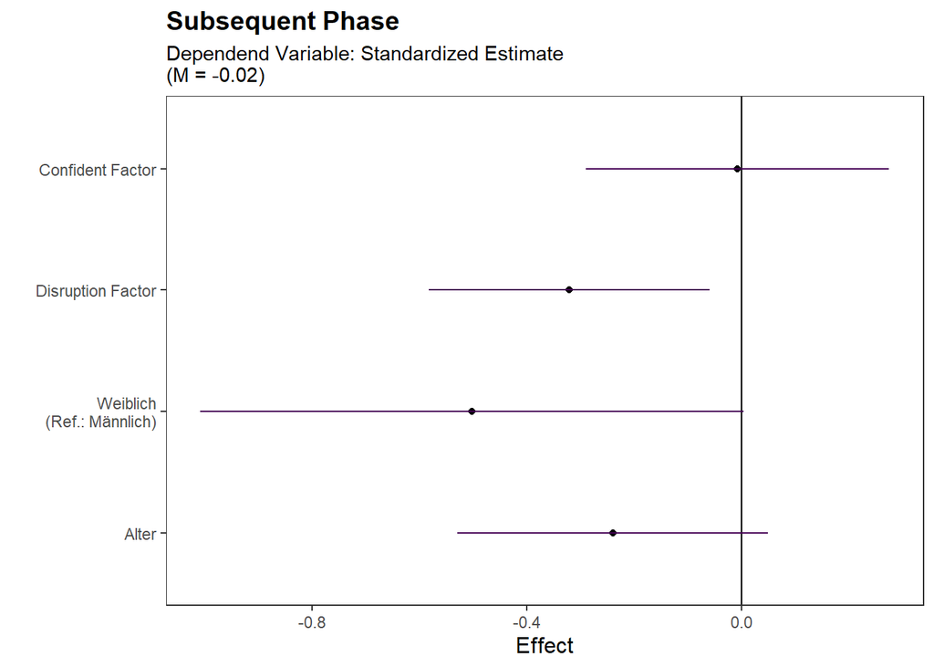

- Nach der Erhebung fällt die HR der Personen, die sich stärker gestört gefühlt haben, *signifikant stärker* ab

## Main Phase vs. Interview Phase

- Main Phase = 10 Minuten ab Lektionsbeginn
- Interview Phase = 10 Minuten mittig vom Interview (Differenz vom Ende der Unterrichtseinheit und von take off watch - die Länge des Zeitraumes, wo die 10 Minuten mittig reinlegt werden –> diese Länge wurde nochmals halbiert, um zur Mitte des Intervalls zu kommen und 5 Minuten abgezogen, um am Start des 10-Minuten-Intervalls zu landen)

Plan:

- Partielle Korrelation (mittlere HR x …)
- Mittelwertvergleich

### Partielle Korrelationen

#### Main Phase

|  | heart_rate_m | confident_factor_m | disruption_factor_m | gender | age |
| --- | --- | --- | --- | --- | --- |
| heart_rate_m | 1.0000000 | -0.0692426 | -0.0623946 | 0.0417891 | -0.0102088 |
| confident_factor_m | -0.0692426 | 1.0000000 | -0.1335813 | 0.0016541 | 0.4360733 |
| disruption_factor_m | -0.0623946 | -0.1335813 | 1.0000000 | 0.0372569 | -0.2411147 |
| gender | 0.0417891 | 0.0016541 | 0.0372569 | 1.0000000 | -0.0594371 |
| age | -0.0102088 | 0.4360733 | -0.2411147 | -0.0594371 | 1.0000000 |

|  | heart_rate_m | confident_factor_m | disruption_factor_m | gender | age |
| --- | --- | --- | --- | --- | --- |
| heart_rate_m | 0.0000000 | 0.6055215 | 0.6417220 | 0.7554479 | 0.9393732 |
| confident_factor_m | 0.6055215 | 0.0000000 | 0.3174712 | 0.9901681 | 0.0006222 |
| disruption_factor_m | 0.6417220 | 0.3174712 | 0.0000000 | 0.7812733 | 0.0682573 |
| gender | 0.7554479 | 0.9901681 | 0.7812733 | 0.0000000 | 0.6576227 |
| age | 0.9393732 | 0.0006222 | 0.0682573 | 0.6576227 | 0.0000000 |

#### Interview Phase

|  | heart_rate_m | confident_factor_m | disruption_factor_m | gender | age |
| --- | --- | --- | --- | --- | --- |
| heart_rate_m | 1.0000000 | -0.1037330 | 0.1771744 | -0.0826475 | 0.0036833 |
| confident_factor_m | -0.1037330 | 1.0000000 | -0.1063598 | -0.0092613 | 0.4127507 |
| disruption_factor_m | 0.1771744 | -0.1063598 | 1.0000000 | 0.0279090 | -0.2741021 |
| gender | -0.0826475 | -0.0092613 | 0.0279090 | 1.0000000 | -0.0974011 |
| age | 0.0036833 | 0.4127507 | -0.2741021 | -0.0974011 | 1.0000000 |

|  | heart_rate_m | confident_factor_m | disruption_factor_m | gender | age |
| --- | --- | --- | --- | --- | --- |
| heart_rate_m | 0.0000000 | 0.4425516 | 0.1873493 | 0.5410683 | 0.9783065 |
| confident_factor_m | 0.4425516 | 0.0000000 | 0.4310207 | 0.9454882 | 0.0014192 |
| disruption_factor_m | 0.1873493 | 0.4310207 | 0.0000000 | 0.8367283 | 0.0390863 |
| gender | 0.5410683 | 0.9454882 | 0.8367283 | 0.0000000 | 0.4710404 |
| age | 0.9783065 | 0.0014192 | 0.0390863 | 0.4710404 | 0.0000000 |

### t-Test

- Paired t-Test
- Idee: Vorher standardisieren anhand von allen Herzraten-Daten
  - Mittlere Herzrate über alle Datenpunkte = beste Schätzung für den realen Mittelwert

$$z_{Phase}=\frac{x_{Phase}-M_{overall}}{SD_{overall}}$$

```
##
##  Paired t-test
##
## data:  tib_test$interview and tib_test$main
## t = -11.521, df = 59, p-value < 2.2e-16
## alternative hypothesis: true difference in means is not equal to 0
## 95 percent confidence interval:
##  -2.987643 -2.103439
## sample estimates:
## mean of the differences
##               -2.545541
```

Ohne Standardisierung:

```
##
##  Paired t-test
##
## data:  tib_test_einfach$interview and tib_test_einfach$main
## t = -12.301, df = 59, p-value < 2.2e-16
## alternative hypothesis: true difference in means is not equal to 0
## 95 percent confidence interval:
##  -20.44837 -14.72644
## sample estimates:
## mean of the differences
##                -17.5874
```

- Beide Testresultate zeigen einen signifikanten Unterschied